# Q1 Generating Random Networks

## Q 2.4 Personalized PageRank

While the use of PageRank has proven very effective, the web’s rapid growth in size and diversity drives an increasing demand for greater flexibility in ranking. Ideally, each user should be able to define their own notion of importance for each individual query.

(a) Suppose you have your own notion of importance. Your interest in a node is proportional to the node’s PageRank, because you totally rely upon Google to decide which website to visit (assume that these nodes represent websites). Again, use random walk on network generated in question 3 to simulate this personalized PageRank. Here the teleportation probability to each node is proportional to its PageRank (as opposed to the regular PageRank, where at teleportation, the chance of visiting all nodes are the same and equal to 1/N). Again, let the teleportation probability be equal to α = 0.2. Compare the results with 3(a).

(b) Find two nodes in the network with median PageRanks. Repeat part 4(a) if teleportations land only on those two nodes (with probabilities 1/2, 1/2). How are the PageRank values affected?

(c) More or less, 4(b) is what happens in the real world, in that a user browsing the web only teleports to a set of trusted web pages. However, this is against the assumption of normal PageRank, where we assume that people’s interest in all nodes are the same. Can you take into account the effect of this self-reinforcement and adjust the PageRank equation?

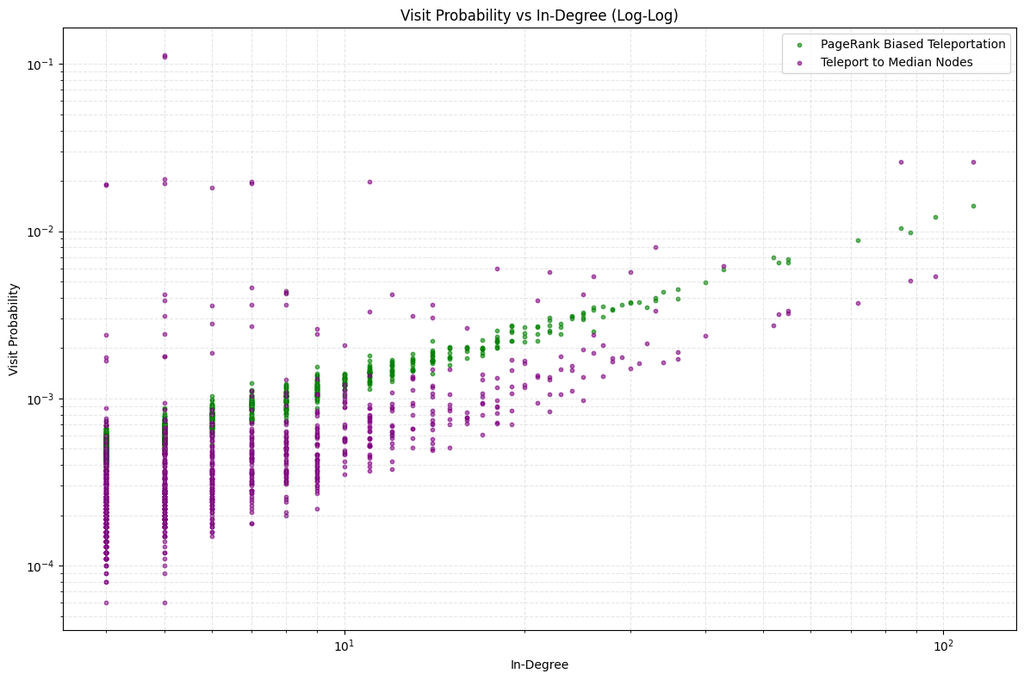

```
PageRank of median node 1: 0.0007010148927129625
PageRank of median node 2: 0.0007014204108930892
```

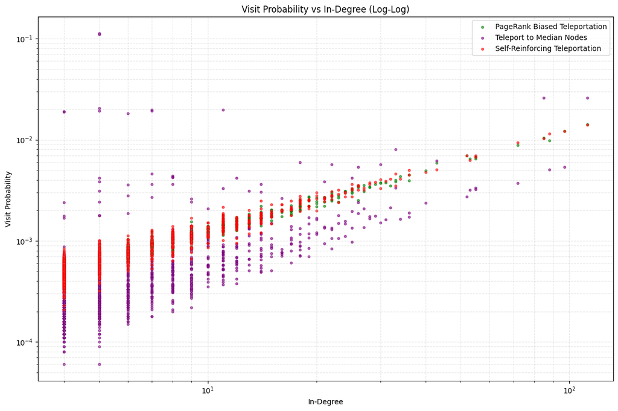

```python
import igraph as ig
import numpy as np
import matplotlib.pyplot as plt
import random
from collections import Counter

# Parameters
N = 1000                # Number of nodes in the preferential attachment graph
m = 4                   # Each new node attaches to m existing nodes
steps = 100000          # Total steps for the random walk
alpha = 0.2             # Teleportation probability

def create_preferential_attachment_graph(N, m):
    """Creates a directed preferential attachment graph."""
    return ig.Graph.Barabasi(n=N, m=m, directed=False).as_directed()

def random_walk(
    G,
    steps=100000,
    teleport=False,
    alpha=0.2,
    teleport_nodes=None,
    teleport_probs=None,
    pagerank_bias=False,
    pagerank=None
):
    """Performs a random walk on graph G, optionally with teleportation."""
    visit_count = Counter()
    nodes = list(range(G.vcount()))
    current = random.choice(nodes)

    for _ in range(steps):
        visit_count[current] += 1

        if teleport and random.random() < alpha:
            if pagerank_bias:
                # Teleportation probability proportional to PageRank
                current = random.choices(nodes, weights=pagerank, k=1)[0]
            elif teleport_nodes is not None:
                # Teleport only to specified nodes
                current = random.choices(teleport_nodes, weights=teleport_probs, k=1)[0]
            else:
                # Uniform teleportation
                current = random.choice(nodes)
        else:
            neighbors = G.successors(current)
            if neighbors:
                current = random.choice(neighbors)
            else:
                # If no outgoing edges, teleport or restart
                current = random.choice(nodes)

    total_visits = sum(visit_count.values())
    visit_prob = {node: count / total_visits for node, count in visit_count.items()}
    return visit_prob

def plot_visit_vs_indegree(G, visit_prob, label, color):
    """Plots visit probability vs in-degree on a log-log scale."""
    in_degrees = G.degree(mode="in")
    x = []
    y = []

    for node, prob in visit_prob.items():
        deg = in_degrees[node]
        x.append(deg)
        y.append(prob)

    plt.scatter(x, y, label=label, alpha=0.6, s=10, color=color)

# Create graph
G = create_preferential_attachment_graph(N, m)

# Compute PageRank
pagerank_values = G.pagerank()
pagerank_dict = {i: pagerank_values[i] for i in range(G.vcount())}

# Perform random walk with PageRank-biased teleportation
visit_prob_pagerank_bias = random_walk(
    G,
    steps,
    teleport=True,
    alpha=alpha,
    pagerank_bias=True,
    pagerank=pagerank_values
)

# Find two nodes with median PageRanks
median_pagerank = np.median(pagerank_values)
median_nodes = [node for node, rank in pagerank_dict.items() if abs(rank - median_pagerank) < 1e-6]

if len(median_nodes) < 2:
    # Find the two nodes closest to the median PageRank
    sorted_nodes = sorted(pagerank_dict.items(), key=lambda x: abs(x[1] - median_pagerank))
    median_nodes = [sorted_nodes[0][0], sorted_nodes[1][0]]
else:
    median_nodes = median_nodes[:2]

# Perform random walk with teleportation to median nodes
teleport_probs = [0.5, 0.5]
visit_prob_median_teleport = random_walk(
    G,
    steps,
    teleport=True,
    alpha=alpha,
    teleport_nodes=median_nodes,
    teleport_probs=teleport_probs
)

# Plotting
plt.figure(figsize=(12, 8))
plot_visit_vs_indegree(G, visit_prob_pagerank_bias, label="PageRank Biased Teleportation", color='green')
plot_visit_vs_indegree(G, visit_prob_median_teleport, label="Teleport to Median Nodes", color='purple')

plt.xscale("log")
plt.yscale("log")
plt.xlabel("In-Degree")
plt.ylabel("Visit Probability")
plt.title("Visit Probability vs In-Degree (Log-Log)")
plt.legend()
plt.grid(True, which="both", ls="--", alpha=0.3)
plt.tight_layout()
plt.show()

# Print PageRank values for the two median nodes
print(f"PageRank of median node 1: {pagerank_dict[median_nodes[0]]}")
print(f"PageRank of median node 2: {pagerank_dict[median_nodes[1]]}")

def self_reinforcing_random_walk(G, steps=100000, alpha=0.2):
    """Performs a self-reinforcing random walk where teleportation targets are based on past visit counts."""
    visit_count = Counter()
    nodes = list(range(G.vcount()))
    current = random.choice(nodes)
    epsilon = 1e-6  # To avoid division by zero early on

    for _ in range(steps):
        visit_count[current] += 1

        if random.random() < alpha:
            # Self-reinforcing teleportation: more visited nodes are more likely to be chosen
            visit_weights = [visit_count[n] + epsilon for n in nodes]
            current = random.choices(nodes, weights=visit_weights, k=1)[0]
        else:
            neighbors = G.successors(current)
            if neighbors:
                current = random.choice(neighbors)
            else:
                current = random.choice(nodes)

    total_visits = sum(visit_count.values())
    visit_prob = {node: count / total_visits for node, count in visit_count.items()}
    return visit_prob

# Run the self-reinforcing version
visit_prob_self_reinforcing = self_reinforcing_random_walk(G, steps, alpha=alpha)

# Plot
plt.figure(figsize=(12, 8))
plot_visit_vs_indegree(G, visit_prob_pagerank_bias, label="PageRank Biased Teleportation", color='green')
plot_visit_vs_indegree(G, visit_prob_median_teleport, label="Teleport to Median Nodes", color='purple')
plot_visit_vs_indegree(G, visit_prob_self_reinforcing, label="Self-Reinforcing Teleportation", color='red')

plt.xscale("log")
plt.yscale("log")
plt.xlabel("In-Degree")
plt.ylabel("Visit Probability")
plt.title("Visit Probability vs In-Degree (Log-Log)")
plt.legend()
plt.grid(True, which="both", ls="--", alpha=0.3)
plt.tight_layout()
plt.show()
```

(a) Comparing with 3(a) we see that the probability of visting a node remains positively correlated with its in-degree. When compared to the orange points in 3(a) the green node sin 4(a) seem to have a higher visit probability. Thus the PageRank by Google helps visit nodes higher in visit probability

(b) For 4(b), focusing teleportation on the two nodes that initially had median PageRank values around 0.0007 produces these effects:

The correlation between in-degree and visit probability weakens substantially. The purple data points appear scattered, showing that in-degree is no longer a reliable predictor.

Some low in-degree nodes show higher visit probabilities than expected, likely due to network proximity to one of the median nodes.

The inherent link structure of the network is overshadowed, resulting in the skewed importance of the teleported median nodes.

(c) In real-world browsing , users tend to revisit popular sites or sites they have visited before, creating a self-reinforcing effect. This is modelled by the teleportation behavior, where the probablity of jumping to node increases with its past visit count.

This makes the ranking system more adaptive to user behavior but also introduces bia by reinforing early popularity